# Who votes against the government?

17 January 2015

## Motivation

## Motivation

### Voting is about more than elections…

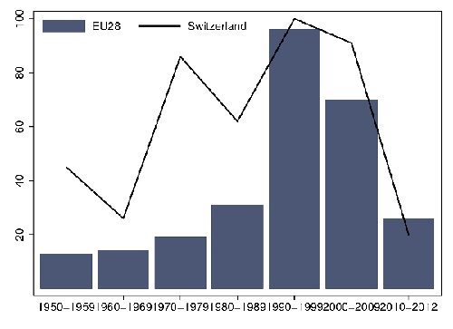

Referendums per decade. Source: (Leininger 2015)

## Motivation

### A defeat and embarassment for the government…

**Federal popular initiative "against mass immigration"** (*Eidgenössische Volksinitiative "Gegen Masseneinwanderung"*)

[figure not shown]

On 9 February 2014 50.3% voted for the initiative "Gegen Masseneinwanderung"

## Motivation

### Referendums in Switzerland

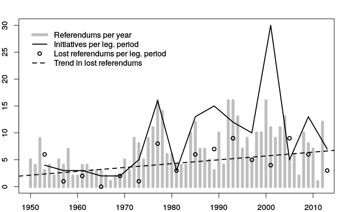

Swiss national referendums, 1950-2012. Source of data: swissvotes.ch

## Motivation

### Types of referendums

1. Obligatory Referendums
   - mandatory for constitutional changes or joing suprational organisations
2. Facultative Referendums
   - referendum on a law if 50,000 signature were collected within 100 days of pasage of law
3. Initiative
   - partial revision of the constitution, 100,000 signaturs
4. Counter-Proposals
   - government may put a counter-proposal on the ballot; initiative committee may withdraw or uphold it's initiative

## Motivation

### Type

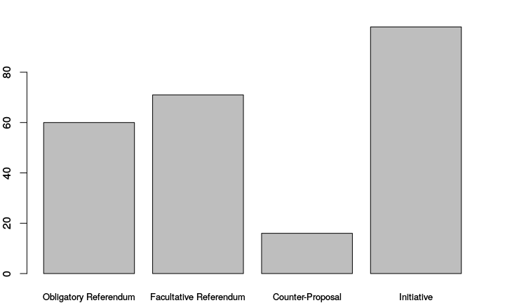

Number of referendums by type, 1981-2010. VoxIt data.

## Motivation

### Topic

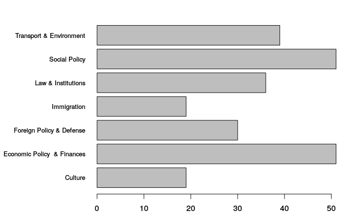

Number of referendums by topic, 1981-2010. VoxIt data.

## Motivation

### Voting against the government

- 'yes' and 'no' can imply different things
- recode to 1 = voted against government recommendation, 0 = followed government recommendation
- allows comparative study of referendums of different and topics
  - even across borders (given comparability of survey data)
- drawback: government vote recommendation or other means of obtaining credible government position a prerequisite

## Motivation

### Relevance

1. A 'tool for populists'
   - understanding motivation of those who voter against the government
2. Rise in government defeats
   - understanding individual-level correlates as potential source of macro-level trends

## Voting against the government

## Voting against the government

### Literature

- Small, scattered and little comparative literature on referendum voting.
- "When studying referendum behavior it is thus not warranted to indiscriminately draw on findings concerning electoral behavior." (Schoen 2012, 514)
- "Decisions on 'big' issues […] are not abstract exercises in constitutional design using copious information about the payoffs of alternative outcomes. Rather, operating in situations of great uncertainty, voters use heuristics provided by the political context in which the referendum occurs. Prime candidates are party identifications, party leader images and government performance evaluations." (Clarke, Kornberg, and Stewart 2004, 355)

## Voting against the government

### Questions

- Descriptive approach
  - obtaining correlations
  - not identifying a determinant
- Questions
  - e.g. *Are voters who are more knowledgeable about a proposal less likely to vote against it?*

## Voting against the government

### Explanatory Variables

- Age
- Gender
- University education
- Region: Swiss-German, Romandie, Italian Switzerland
- Knows title and content of referendum, one of the two or neither
- Type: Obligatory Referendum, Facultative Referendum, Counter-Proposal, Initiative
- Governing Party Unity

## Data & Empirics

## Data & Empirics

### Data

- VoxIt: cumulation of Vox post-referendum surveys
- 85 nationaly representative surveys (*scrutins*) covering 245 national referendums (*projets*) between 1981 and 2010 (96.5% of referendums in that period).
- 135960 observations based on 49253 unique respondents.
- On average 555 (\(s\): 126) observations per referendum.

## Results

## Results

### Model estimates

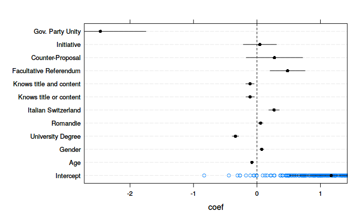

## Results

### Age and Gender

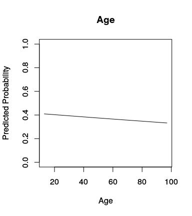

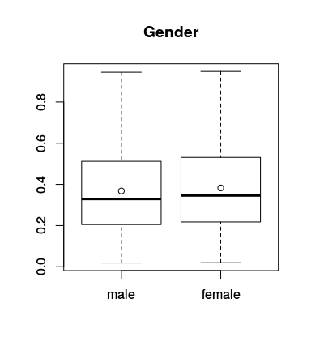

## Results

### Education and Region

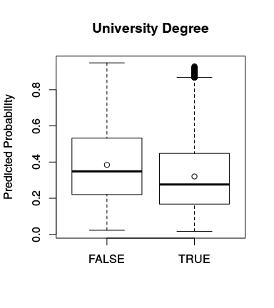

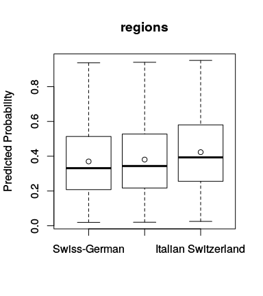

## Results

### Referendum specific knowledge

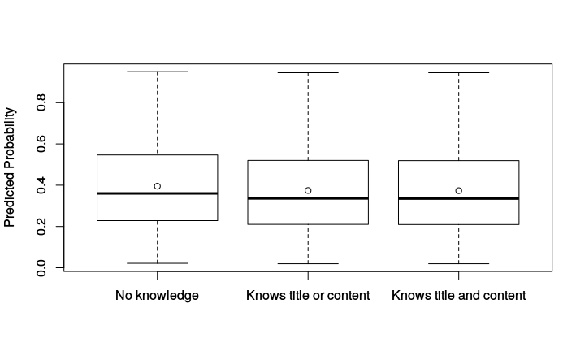

## Results

### Type & Governing Party Unity

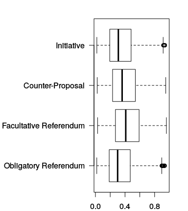

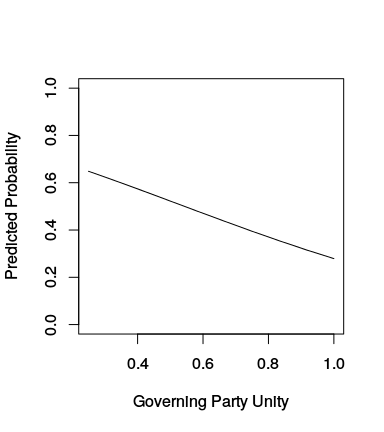

## Discussion

## Discussion

### Preliminary Conclusions

- Voting against the government provides a framework for comparative analysis of referendum voting.
- Initial results
  - Less well-informed and educated more likely to vote against the government.
  - Type and party signals seem to matter.
- Akin to incumbent vote
  - Allows testing of whether and when classic predictors of electoral behavior 'work'

## Discussion

### Extending the model

- Knowledge of the government's position
- Likely impact of the proposal
- Party identification
  - party identification with governing party
  - interaction with party *paroles*
- Left-right self-placement
- Campaigns
  - hard to measure
  - available measures focus on limited timeframe
- Interactions with time: do correlations change over time?

## Discussion

### Who are the deviators?

**How could one, among the voters 'defying' the government, for instance, distinguish 'reasoned' from 'populist deviators'?**

- e.g. 'reasoned' deviators are informed about topic and can provide arguments
- e.g. 'populist' deviators have no party identification
- not necessarily exhaustive categories

## Discussion

### What explains the trend?

**How can an analysis of individual voting behavior contribute to explaining the macro-level trend in rising numbers of government defeats?**

- How are individual- and macro-level predictors trending?
  - e.g. share of population with university degree
  - or type of referendums (likely not the initiative)
  - or decrease in party identification / satisfaction with democracy
  - not always straightforward: is age an age or generation 'effect'?

## Thank you!

https://github.com/aleininger/votingreferendums

a.leininger at phd.hertie-school dot org

[`@`a_leininger](https://twitter.com/a_leininger)

## References

Clarke, Harold D., Allan Kornberg, and Marianne C. Stewart. 2004. “Referendum Voting as Political Choice: The Case of Quebec.” *British Journal of Political Science* 34 (02): 345–55. doi:10.1017/S0007123404000092.

Leininger, Arndt. 2015. “Direct Democracy in Europe. Potentials and Pitfalls.” *Global Policy* forthcoming.

Schoen, Harald. 2012. “Wählen Und Abstimmen - Zwei Seiten Einer Medaille? Eine Analyse Am Beispiel Des Volksentscheids Zum Nichtraucherschutz in Bayern.” *Politische Vierteljahresschrift* Sonderheft 45: 514–35.